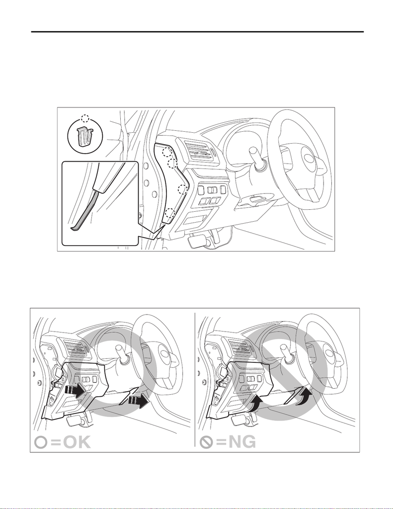

Instrument Panel Lower Cover

EXTERIOR/INTERIOR TRIM

18.Instrument Panel Lower Cover

A: REMOVAL

1) Disconnect the ground cable from battery and wait for at least 60 seconds before starting work. <Ref. to

NT-5, BATTERY, NOTE, Note.>

NOTE:

For models other than STI model, disconnect the ground terminal from battery sensor.

2) Remove the clips, and remove the cover - instrument panel side LH.

NOTE:

Using a plastic remover, open the cover - instrument panel side LH.

3) Remove the cover assembly - instrument panel LWR driver INN and OUT.

CAUTION:

When removing the cover assembly - instrument panel LWR driver, be sure to pull it toward you. If at-

tempting to remove by turning it upward, the claws may be damaged.

(1) Remove the screws and release the clips and claws.

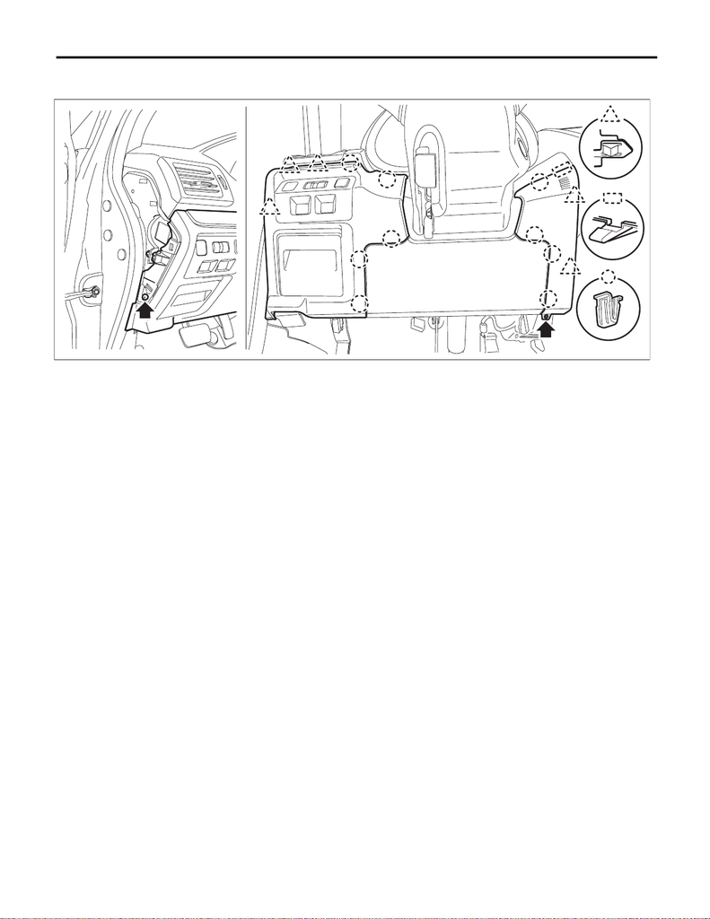

Instrument Panel Lower Cover

EXTERIOR/INTERIOR TRIM

(2) Disconnect the harness connectors, and remove the cover assembly - instrument panel LWR driver

INN and OUT.

B: INSTALLATION

1) Install the cover assembly - instrument panel LWR driver INN and OUT.

2) Install the cover - instrument panel side LH.

3) Connect the battery ground terminal. <Ref. to NT-5, BATTERY, NOTE, Note.>

NOTE:

For models other than STI model, connect the ground terminal to battery sensor.